# Exercises 2

Carlton Washburn

August 15, 2015

## Flights at ABIA

The first plot we will look at is the the proportion of flights that were cancelled by carrier.

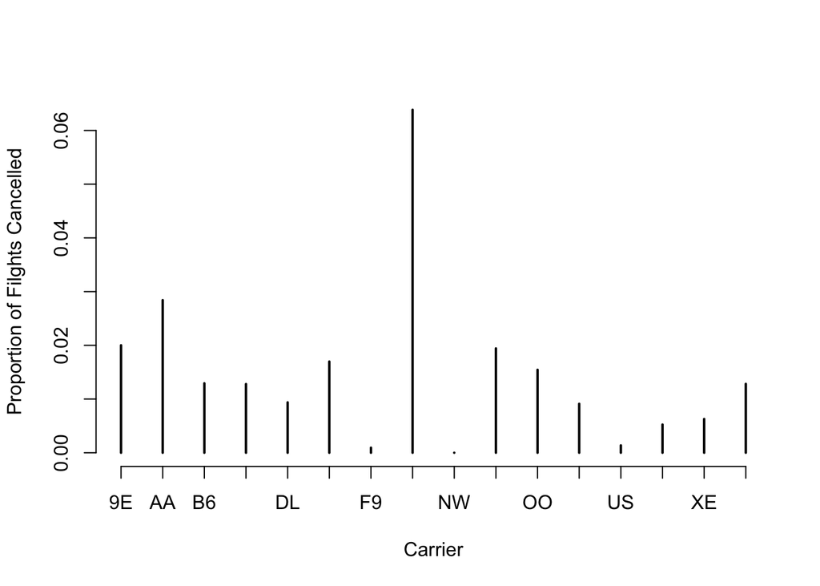

The next two plots we will look at are the Average delay in arrival or departure for every day of the year.

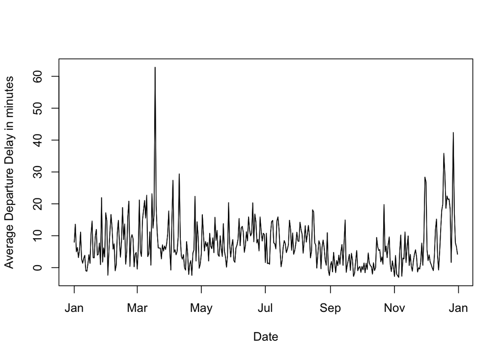

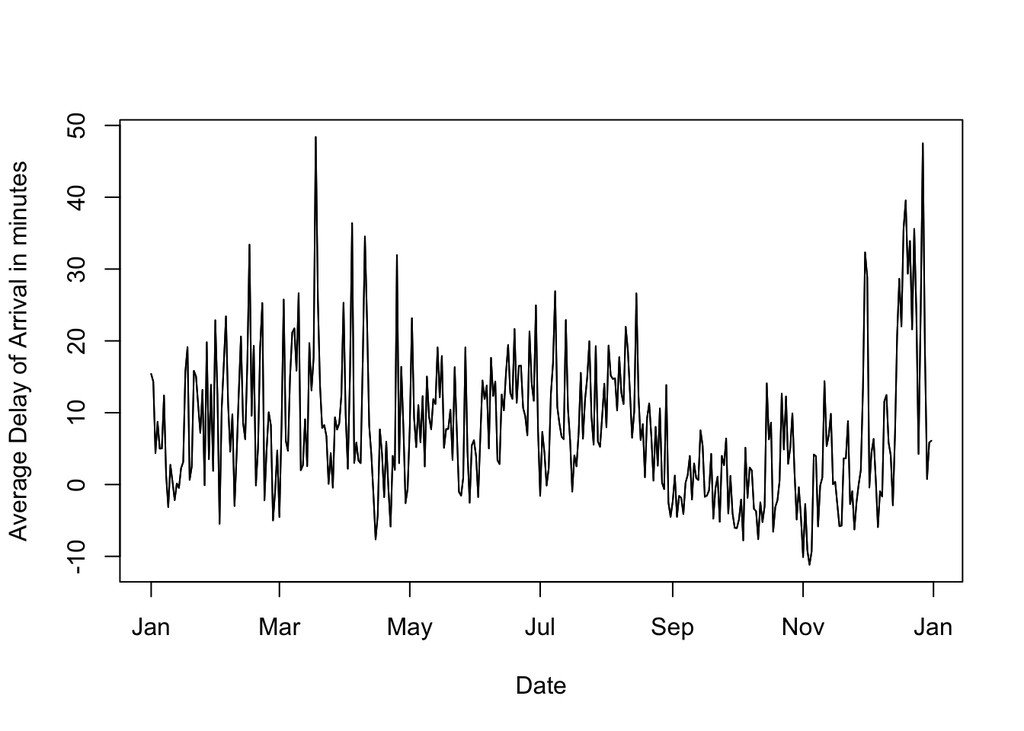

### Author Attribution

In the following section, we try to predict the author of an article based on the words in the article. First we attempt Naive-Bayes.

```r
library(tm)
```

```r
readerPlain = function(fname){
  readPlain(elem=list(content=readLines(fname)),
            id=fname, language='en') }
author_train = Sys.glob('./ReutersC50/C50train/*')
author_test = Sys.glob('./ReutersC50/C50tests/*')
author_dirs = c(author_train,author_test)
file_list = NULL
labels = NULL
for(author in author_dirs) {
  author_name = substring(author, first=23)
  files_to_add = Sys.glob(paste0(author, '/*.txt'))
  file_list = append(file_list, files_to_add)
  labels = append(labels, rep(author_name, length(files_to_add)))
}
all_docs = lapply(file_list, readerPlain)
names(all_docs) = file_list
names(all_docs) = sub('.txt', '', names(all_docs))

my_corpus = Corpus(VectorSource(all_docs))
names(my_corpus) = file_list
my_corpus = tm_map(my_corpus, content_transformer(tolower)) # make everything lowercase
my_corpus = tm_map(my_corpus, content_transformer(removeNumbers)) # remove numbers
my_corpus = tm_map(my_corpus, content_transformer(removePunctuation)) # remove punctuation
my_corpus = tm_map(my_corpus, content_transformer(stripWhitespace)) ## remove excess white-space
my_corpus = tm_map(my_corpus, content_transformer(removeWords), stopwords("SMART"))

DTM = DocumentTermMatrix(my_corpus)
DTM = removeSparseTerms(DTM, 0.975)
X = as.matrix(DTM)
authors = levels(as.factor(labels))
i = 0;
w = NULL
smooth_count = 1/nrow(X)
for (author in authors) {
  col = NULL
  train = X[((i*50)+1):((i*50)+50),]
  col = colSums(train + smooth_count)
  names(col) = colnames(train)
  temp = col/sum(col)
  w = cbind(w,temp)
  i = i+1
}
colnames(w) = authors

fit = matrix(nrow = 2500, ncol = 50)
test = X[2501:5000,]
for (i in seq(1:2500)){
  for ( j in seq(1:50)){
    fit[i,j] = sum(test[i,]*log(w[,j]))
  }
}
colnames(fit) = authors
labels_fit = apply(fit,1,which.max)
author_fit = authors[labels_fit]

good = 0
for (i in seq(1, 2500)){
  if (author_fit[i] == labels[2500+i]){
    good = good + 1
  }
}
good/2500
```

```
## [1] 0.5228
```

We get a 52 percent accuracy with naive-bayes. Now lets try to predict the author with principle component analysis and a random forest.

```r
library(randomForest)
train = X[1:2500,]
test = X[2501:5000,]

pca = prcomp(train)

test.p = predict(pca,newdata = test)

train.pca = pca$x[,1:100]
forest = randomForest(train.pca,y = as.factor(labels[1:2500]),ntree = 200)

predicted = predict(forest,test.p,type = 'response')
good = 0
for (i in seq(1:2500)){
  if (predicted[i] == labels[2500+i]) {
    good = good + 1
  }
}
good/2500
```

```
## [1] 0.4996
```

With principle component analysis and a random forest we get an accuracy of around 50 percent, which is not much worse then Naive Bayes.

### Association Rule Mining

We now attempt some association rule mining with a grocery data set.

```r
library(arules)
grocery = read.transactions('./groceries.txt', sep = ',', format = 'basket', rm.duplicates = 1)

groceryrules <- apriori(grocery,parameter=list(support=.01, confidence=.5, maxlen=4))
```

```
##
## Parameter specification:
##  confidence minval smax arem  aval originalSupport support minlen maxlen
##         0.5    0.1    1 none FALSE            TRUE    0.01      1      4
##  target   ext
##   rules FALSE
##
## Algorithmic control:
##  filter tree heap memopt load sort verbose
##     0.1 TRUE TRUE  FALSE TRUE    2    TRUE
##
## apriori - find association rules with the apriori algorithm
## version 4.21 (2004.05.09)        (c) 1996-2004   Christian Borgelt
## set item appearances ...[0 item(s)] done [0.00s].
## set transactions ...[169 item(s), 9835 transaction(s)] done [0.00s].
## sorting and recoding items ... [88 item(s)] done [0.00s].
## creating transaction tree ... done [0.00s].
## checking subsets of size 1 2 3 4 done [0.00s].
## writing ... [15 rule(s)] done [0.00s].
## creating S4 object  ... done [0.00s].
```

```r
inspect(groceryrules)
```

```
##    lhs                     rhs                   support confidence     lift
## 1  {curd,
##     yogurt}             => {whole milk}       0.01006609  0.5823529 2.279125
## 2  {butter,
##     other vegetables}   => {whole milk}       0.01148958  0.5736041 2.244885
## 3  {domestic eggs,
##     other vegetables}   => {whole milk}       0.01230300  0.5525114 2.162336
## 4  {whipped/sour cream,
##     yogurt}             => {whole milk}       0.01087951  0.5245098 2.052747
## 5  {other vegetables,
##     whipped/sour cream} => {whole milk}       0.01464159  0.5070423 1.984385
## 6  {other vegetables,
##     pip fruit}          => {whole milk}       0.01352313  0.5175097 2.025351
## 7  {citrus fruit,
##     root vegetables}    => {other vegetables} 0.01037112  0.5862069 3.029608
## 8  {root vegetables,
##     tropical fruit}     => {other vegetables} 0.01230300  0.5845411 3.020999
## 9  {root vegetables,
##     tropical fruit}     => {whole milk}       0.01199797  0.5700483 2.230969
## 10 {tropical fruit,
##     yogurt}             => {whole milk}       0.01514997  0.5173611 2.024770
## 11 {root vegetables,
##     yogurt}             => {other vegetables} 0.01291307  0.5000000 2.584078
## 12 {root vegetables,
##     yogurt}             => {whole milk}       0.01453991  0.5629921 2.203354
## 13 {rolls/buns,
##     root vegetables}    => {other vegetables} 0.01220132  0.5020921 2.594890
## 14 {rolls/buns,
##     root vegetables}    => {whole milk}       0.01270971  0.5230126 2.046888
## 15 {other vegetables,
##     yogurt}             => {whole milk}       0.02226741  0.5128806 2.007235
```

We see from our rule mining that carts with vegetables and some dairy product usually include whole milk. We also see that carts with fruits and vegetables usually leads to more vegetables. The support is the minimum fraction that contain the itemsets, the confidence is how often the one itemset appears with another itemset.